# Similarity and heterogeneity

## Overview

Another central concept in social network analysis is that of similarity between vertices.

> In what ways can two actors in a network be similar, and how can we quantify this similarity?

Similarity is relevant in at least two important applications:

- **recommender systems**, where the goal is to suggest to a user new products to buy according to what similar users bought or liked, and
- **link prediction**, where the task is to predict new connections for a user on social networks according to the connections of similar users.

## Similarity

Similarity agrees with the following thesis:

> Two nodes are similar to each other if they share many neighbors.

For instance, two customers are similar if they bought the same products (Amazon), or view the same movies (Netflix), or listen to the same music (Spotify).

## Notation

- let \(A = (a_{i,j})\) be the adjacency matrix of a possibly weighted graph
- the general idea is to associate each node \(i\) with a \(i\)th row (or column) of the adjacency matrix (a vector of size the number of nodes of the graph)
- the similarity (or dissimilarity) of two nodes \(i\) and \(j\) is then measured using a similarity (or distance) function among the associated vectors

## Notation

Let us focus on unweighted undirected graphs with \(n\) nodes.

We denote with \[k_i = \sum_k A_{i,k}\] the degree of node \(i\) and with \[n_{i,j} = \sum_k A_{i,k} A_{j,k}\] the number of neighbors that nodes \(i\) and \(j\) have in common.

Moreover, \(A_i\) is the \(i\)-th row of \(A\), a boolean (0-1) vector of length \(n\).

## Cosine similarity

> The cosine similarity \(\sigma_{i,j}\) of nodes \(i\) and \(j\) is the cosine of the angle between vectors \(A_i\) and \(A_j\).

\[ \sigma_{i,j} = \cos (A_i, A_j) = \frac{A_i \cdot A_j}{\|A_i\| \|A_j\|} = \frac{\sum_k A_{i,k} A_{j,k}}{\sqrt{\sum_k A_{i,k}^{2}} \sqrt{\sum_k A_{j,k}^{2}}} \]

The measure runs from 0 (orthogonal vectors or maximum dissimilarity) to 1 (parallel vectors or maximum similarity).

Since the involved vectors are 0-1 vectors, we have that:

\[ \sigma_{i,j} = \frac{n_{i,j}}{\sqrt{k_i k_j}} \]

That is, cosine similarity between \(i\) and \(j\) is the number of neighbors shared by \(i\) and \(j\) divided by the geometric mean of their degrees.

## Pearson similarity

An alternative similarity measure is **Pearson correlation coefficient**:

> The similarity \(\sigma_{i,j}\) of nodes \(i\) and \(j\) is the correlation coefficient between vectors \(A_i\) and \(A_j\)

\[ \sigma_{i,j} = \frac{cov(A_i, A_j)}{sd(A_i) \, sd(A_j)} = \frac{\sum_k (A_{i,k} - \langle A_i \rangle) (A_{j,k} - \langle A_j \rangle)} {\sqrt{\sum_k (A_{i,k} - \langle A_i \rangle)^{2}} \sqrt{\sum_k (A_{j,k} - \langle A_j \rangle)^{2}}} \]

The measure runs from -1 (maximum negative correlation or maximum dissimilarity) to 1 (maximum positive correlation or maximum similarity). Notice that values close to \(0\) indicate no correlation, hence neither similarity nor dissimilarity.

Again, since the involved vectors are 0-1 vectors, it is not difficult to see that the numerator of the correlation coefficient, that is the co-variance between vectors \(A_i\) and \(A_j\) is:

\[ cov(A_i, A_j) = n_{i,j} - \frac{k_i k_j}{n} \]

Notice that \(k_i k_j/n\) is the expected number of common neighbors between \(i\) and \(j\) if they would choose their neighbors at random: the probability that a random neighbor of \(i\) is also a neighbor of \(j\) is \(k_j / n\), hence the expected number of common neighbors between \(i\) and \(j\) is \(k_i k_j/n\).

Hence a positive covariance, or a similarity between \(i\) and \(j\), holds when \(i\) and \(j\) share more neighbors than we would expect by change, while a negative covariance, or a dissimilarity between \(i\) and \(j\) happens when \(i\) and \(j\) have less neighbors in common than we would expect by change.

## Heterogeneity

We have learnt how to exploit the network topology to gauge the similarity (or dissimilarity) of pairs of networks.

This opens up the possibility of defining a measure of **heterogeneity** for a node in terms of the dissimilarity of its neighbors:

> A node is heterogeneous if it has dissimilar neighbors.

Examples are: **Shannon entropy**, **Simpson diversity** or **Rao quadratic entropy**

For instance:

- an individual is heterogeneous if her friends are ill-matched
- a scholar is heterogeneous if his papers are interdiscipliary

## Case Study: Bigrams as graphs

## Bigrams as graphs

We may be interested in visualizing all of the relationships among words in a corpus.

As one common visualization, we can arrange the words into a **network**

```r
library(igraph)
library(tidygraph)
library(ggraph)
library(tidyverse)
library(tidytext)
library(janeaustenr)


austen_bigrams <- austen_books() %>%
  unnest_tokens(bigram, text, token = "ngrams", n = 2)

austen_bigrams %>%
  glimpse()
```

```
## Rows: 725,049
## Columns: 2
## $ book   <fct> Sense & Sensibility, Sense & Sensibility, Sense & Sensibility,…
## $ bigram <chr> "sense and", "and sensibility", "sensibility by", "by jane", "…
```

## Text preprocessing

```r
# remove stop words
bigrams_separated <- austen_bigrams %>%
  separate(bigram, c("word1", "word2"), sep = " ")

bigrams_filtered <- bigrams_separated %>%
  filter(!word1 %in% stop_words$word) %>%
  filter(!word2 %in% stop_words$word)

# bigram counts
bigram_counts <- bigrams_filtered %>%
  count(word1, word2, sort = TRUE)
```

## Create the graph

```r
# create the graph
bigram_graph <- bigram_counts %>%
  filter(n > 20) %>%
  as_tbl_graph()

bigram_graph
```

```
## # A tbl_graph: 91 nodes and 77 edges
## #
## # A directed acyclic simple graph with 17 components
## #
## # Node Data: 91 x 1 (active)
##   name
##   <chr>
## 1 sir
## 2 miss
## 3 captain
## 4 frank
## 5 lady
## 6 colonel
## # … with 85 more rows
## #
## # Edge Data: 77 x 3
##    from    to     n
##   <int> <int> <int>
## 1     1    28   287
## 2     2    29   215
## 3     3    30   170
## # … with 74 more rows
```

## Visualise the graph

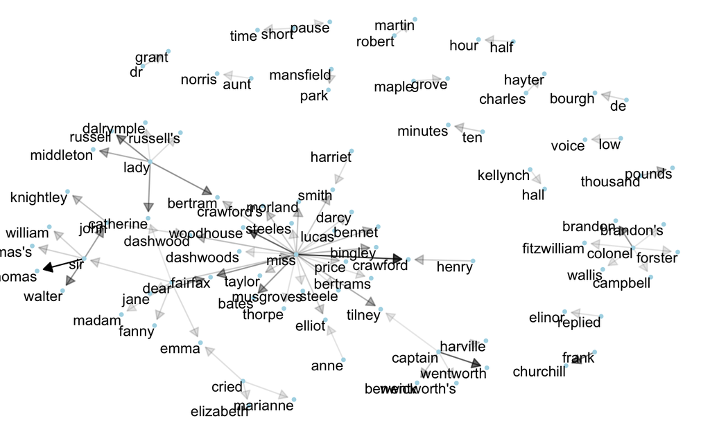

```r
# arrows
a <- grid::arrow(type = "closed", length = unit(.1, "inches"))

# plot the graph
ggraph(bigram_graph, layout = "fr") +
  geom_edge_link(aes(edge_alpha = n), show.legend = FALSE,
                 arrow = a, end_cap = circle(.07, 'inches')) +
  geom_node_point(color = "lightblue", size = 1) +
  geom_node_text(aes(label = name), vjust = 1, hjust = 1) +
  theme_void()
```

- note that this is a visualization of a **Markov chain**, a common model in text processing
- In a Markov chain, each choice of word depends only on the previous word
- in this case, a random generator following this model might spit out “dear”, then “sir”, then “william/walter/thomas/thomas’s”, by following each word to the most common words that follow it

## Co-occurrence of words

- tokenizing by n-gram is a useful way to explore pairs of adjacent words
- however, we may also be interested in words that tend to co-occur within particular documents or particular chapters, **even if they don’t occur next to each other**
- the widyr package makes operations such as computing counts and correlations easy, by simplifying the pattern of *widen data, perform an operation, then re-tidy data*
- the widyr package:
  1. first *casts* a tidy dataset into a wide matrix
  2. performs an operation such as a correlation on it
  3. then re-tidies the result

## Co-occurrence of words: the wider package

```r
library(widyr)

# separate words in sections (10 lines)
austen_section_words <- austen_books() %>%
  filter(book == "Pride & Prejudice") %>%
  mutate(section = row_number() %/% 10) %>%
  filter(section > 0) %>%
  unnest_tokens(word, text) %>%
  filter(!(word %in% stop_words$word))

austen_section_words
```

```
## # A tibble: 37,240 x 3
##    book              section word
##    <fct>               <dbl> <chr>
##  1 Pride & Prejudice       1 truth
##  2 Pride & Prejudice       1 universally
##  3 Pride & Prejudice       1 acknowledged
##  4 Pride & Prejudice       1 single
##  5 Pride & Prejudice       1 possession
##  6 Pride & Prejudice       1 fortune
##  7 Pride & Prejudice       1 wife
##  8 Pride & Prejudice       1 feelings
##  9 Pride & Prejudice       1 views
## 10 Pride & Prejudice       1 entering
## # … with 37,230 more rows
```

```r
# count words co-occuring within sections
word_pairs <- austen_section_words %>%
  pairwise_count(word, section, sort = TRUE)

word_pairs
```

```
## # A tibble: 796,008 x 3
##    item1     item2         n
##    <chr>     <chr>     <dbl>
##  1 darcy     elizabeth   144
##  2 elizabeth darcy       144
##  3 miss      elizabeth   110
##  4 elizabeth miss        110
##  5 elizabeth jane        106
##  6 jane      elizabeth   106
##  7 miss      darcy        92
##  8 darcy     miss         92
##  9 elizabeth bingley      91
## 10 bingley   elizabeth    91
## # … with 795,998 more rows
```

## Co-occurrence of words: correlation coefficient

Pairs like “Elizabeth” and “Darcy” are the most common co-occurring words, but that’s not particularly meaningful since *they’re also the most common individual words*.

We may instead want to examine **correlation** among words, which indicates how often they appear together relative to how often they appear separately.

In particular, here we’ll focus on the [phi coefficient](https://en.wikipedia.org/wiki/Phi_coefficient), a common measure for binary correlation.

The focus of the phi coefficient is how much more likely it is that either **both** word X and Y appear, or **neither** do, than that one appears without the other.

Consider the following table:

|  | Has word Y | No word Y | Total |
| --- | --- | --- | --- |
| Has word X | \(n_{11}\) | \(n_{10}\) | \(n_{1\cdot}\) |
| No word X | \(n_{01}\) | \(n_{00}\) | \(n_{0\cdot}\) |
| Total | \(n_{\cdot 1}\) | \(n_{\cdot 0}\) | n |

In terms of this table, the phi coefficient is:

\[\phi=\frac{n_{11}n_{00}-n_{10}n_{01}}{\sqrt{n_{1\cdot}n_{0\cdot}n_{\cdot0}n_{\cdot1}}}\]

Introduced by Karl Pearson, this measure is similar to the [Pearson correlation coefficient](https://en.wikipedia.org/wiki/Pearson_correlation_coefficient) in its interpretation.

```r
# we need to filter for at least relatively common words first
word_cors <- austen_section_words %>%
  group_by(word) %>%
  filter(n() >= 20) %>%
  pairwise_cor(word, section, sort = TRUE)

word_cors
```

```
## # A tibble: 154,842 x 3
##    item1     item2     correlation
##    <chr>     <chr>           <dbl>
##  1 bourgh    de              0.951
##  2 de        bourgh          0.951
##  3 pounds    thousand        0.701
##  4 thousand  pounds          0.701
##  5 william   sir             0.664
##  6 sir       william         0.664
##  7 catherine lady            0.663
##  8 lady      catherine       0.663
##  9 forster   colonel         0.622
## 10 colonel   forster         0.622
## # … with 154,832 more rows
```

```r
word_cors %>%
  filter(item1 == "pounds")
```

```
## # A tibble: 393 x 3
##    item1  item2     correlation
##    <chr>  <chr>           <dbl>
##  1 pounds thousand       0.701
##  2 pounds ten            0.231
##  3 pounds fortune        0.164
##  4 pounds settled        0.149
##  5 pounds wickham's      0.142
##  6 pounds children       0.129
##  7 pounds mother's       0.119
##  8 pounds believed       0.0932
##  9 pounds estate         0.0890
## 10 pounds ready          0.0860
## # … with 383 more rows
```

Just as we used ggraph to visualize bigrams, we can use it to visualize the correlations and clusters of words that were found by the widyr package.

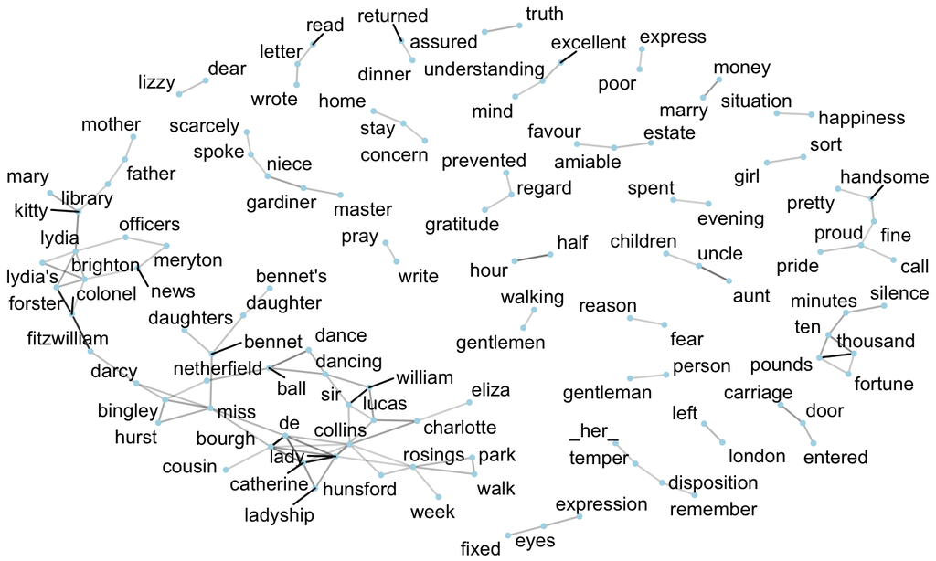

```r
word_cors %>%
  filter(correlation > .15) %>%
  as_tbl_graph() %>%
  ggraph(layout = "fr") +
  geom_edge_link(aes(edge_alpha = correlation), show.legend = FALSE) +
  geom_node_point(color = "lightblue", size = 1) +
  geom_node_text(aes(label = name), repel = TRUE) +
  theme_void()
```

## Thanks for your attetion!

Filippo Chiarello